# Taller corte 3

Mateo Gomez,Miguel Jaimes, Hector Sanjuan, Miguel Lugo, Mateo Molinares

2025-04-30

# Punto 1

## Enunciado

Sea $X_1, X_2, \ldots, X_n$ una muestra de $n$ variables aleatorias independientes, cada una con distribución uniforme en el intervalo $[0, \theta]$.

1. Calcule un estimador insesgado $\hat{\theta}_1$ de $\theta$ basado en el método de momentos.
2. Calcule el estimador de máxima verosimilitud $\hat{\theta}_2$ de $\theta$. ¿Es sesgado?
3. Sea $m = \min(X_1, X_2, \ldots, X_n)$ el mínimo valor de la muestra. Calcule $\mathbb{E}(m)$ y deduzca un estimador insesgado $\hat{\theta}_3$ de $\theta$.
4. Calcule la varianza de $\hat{\theta}_1$, $\hat{\theta}_2$ y $\hat{\theta}_3$.

## Calculo de Estimador 1

Se sabe que la muestra de las n variables tienen distribucion uniforme es decir $X_i \sim Uniforme(0,\theta), \forall i=1,...,n$ por lo que se aplicara el metodo de momentos para encontrar el estimador $\hat{\theta}_1$. como solo hay un estimador $\theta$ solo se debe calcular el primer momento tanto poblacional como muestral. Al ser la distribucion uniforme se sabe que el valor esperado para cada X es
$$\mathbb{E}(X)=\frac{0+\theta}{2}=\frac{\theta}{2}$$
El valor esperado es el primer momento poblacional. Se encuentra ahora el primer momento muestral mediante la formula general
$$M_1=\frac{\sum_{i=1}^n X_i}{n}=\frac{1}{n}\sum_{i=1}^n X_i=\bar{X}$$
Ahora se igualan los 2 momentos para asi encontrar el estimador
$$\bar{X}=\frac{\theta}{2}$$
se despeja $\theta$ para encontrar el estimador
$$2\bar{X}=\hat{\theta}_1$$
Se verifica si el estimador es insesgado
$$\mathbb{E}(2\bar{X})=2\mathbb{E}(\bar{X})=2\mathbb{E}(\frac{\sum_{i=1}^n
X_i}{n})=2\mathbb{E}(\frac{1}{n}\sum_{i=1}^n
X_i)=2(\frac{1}{n}\sum_{i=1}^n \mathbb{E}(X_i))$$
pero como cada $X_i$ pertenece a la distribucion uniforme se sabe que sus valores esperados seran igual a $\frac{\theta}{2}$
$$2(\frac{1}{n}\sum_{i=1}^n
\mathbb{E}(X_i))=2(\frac{1}{n}n\frac{\theta}{2})=2(\frac{\theta}{2})=\theta$$
como $\mathbb{E}(\hat{\theta}_1)=\theta$ el estimador $\hat{\theta_1}$ es insesgado

## Calculo del Estimador 2

Al estar trabajando con la distribucion uniforme, se debe calcular el estimador de maxima verosimilitud y para ello se utilizara la funcion de densidad de probabilidad:
$$f_{X_i}(\theta) =
\begin{cases}
\frac{1}{\theta} & \text{si } 0 \leq X_i \leq \theta, \\
0 & \text{en otro caso.}
\end{cases}$$
se define la funcion L de maxima verosimilitud
$$L(\theta)= \prod_{i=1}^n f_{X_i}(\theta)= \prod_{i=1}^n
\frac{1}{\theta}=\frac{1}{\theta^n}$$
Notemos que al calcular la derivada no se puede despejar para poder encontrar el estimador ya que la derivada nos da
$$\frac{d}{d\theta}(\frac{1}{\theta^n})=-\frac{n}{\theta^{n-1}}$$
por lo que se debe encontrar el estimador a partir de un analisis profundo de $L(\theta)$.

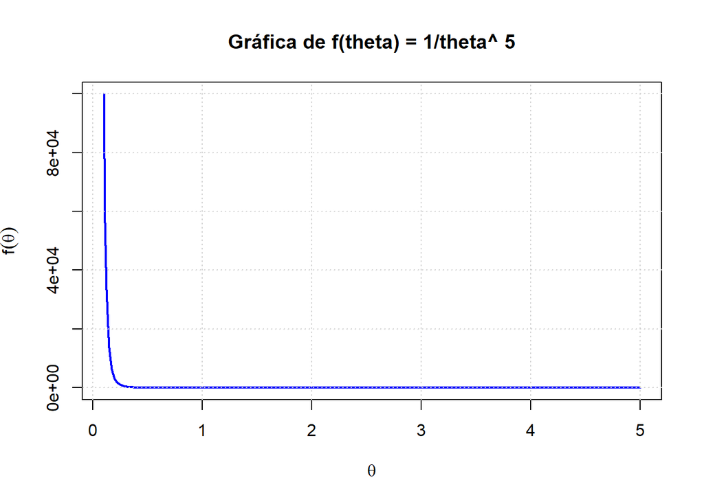

```r
# Parámetro
n <- 5

# Valores de theta
theta <- seq(0.1, 5, length.out = 400)
f_theta <- 1 / theta^n

# Graficar
plot(theta, f_theta, type = "l", lwd = 2, col = "blue",
     main = paste("Gráfica de f(theta) = 1/theta^", n),
     xlab = expression(theta), ylab = expression(f(theta)))
grid()
```

Observemos que $L(\theta)$ es una funcion decreciente y estamos buscando la funcion de maxima verosimilitud en la que se maximiza $\theta$. Note que, queremos entonces maximizar el área bajo la curva de la función, por lo que debemos minimizar el valor de $\theta$ para maximizar dicho valor. Observamos en la muestra que los valores siempre seran menores o iguales a $\theta$ porque sino seran 0 por lo que $\theta$ debe ser al menos tan grande como el mayor valor observado en la muestra osea
$$\theta \geq \max(X_1,...,X_n)$$
por lo que el valor de $L(\theta)$ que maximiza a $\theta$ es el menor $\theta$ que aun satisface la condicion, osea
$$\hat{\theta_2}=\max(X_1,...,X_n)$$
debemos determinar si el estimador es sesgado por lo que se calculara su esperanza mediante su funcion de distribucion acumulativa la cual es
$$F_{X_{\hat{\theta_2}}}(x) =
\begin{cases}
(\frac{x}{\theta})^{n} & \text{si } 0 \leq x \leq \theta, \\
0 & \text{en otro caso.}
\end{cases}$$
derivamos esta ultima para encontrar la funcion de densidad para el $\hat{\theta_2}$
$$f_{\hat{\theta_2}}(x)=\frac{d}{dx}F_{X_{\hat{\theta_2}}}(x)=
n\frac{x^{n-1}}{\theta^n}$$
siendo $0 \leq x \leq \theta$ con esta formula se puede calcular el valor esperado
$$\mathbb{E}(\hat{\theta_2})= \int_{0}^\theta
xn\frac{x^{n-1}}{\theta^n}dx= \frac{n}{\theta^n}\int_{0}^n x^n=
\frac{n}{\theta^n}\left[ \frac{x^{n+1}}{n+1} \right]_0^\theta=
\frac{n}{\theta^n}\frac{\theta^{n+1}}{n+1}= \frac{n}{n+1}\theta$$
al ser $\mathbb{E}(\hat{\theta_2}) \neq \theta$ entonces el estimador es sesgado

## Calculo de Estimador 3

se va a determinar el valor esperado del mínimo de esta muestra, denotado por $m = \min(X_1, X_2, \dots, X_n)$, y luego encontrar un estimador insesgado de $\theta$ utilizando este valor mínimo. Para calcular el valor esperado de $m$ primero se va a encontrar su función de distribución acumulada. Queremos calcular la probabilidad de que el valor mínimo $m$ sea menor o igual a un valor $x$. Lo cual se expresa de la siguiente manera
$$F_m(x) = P(m \leq x) = 1 - P(\text{todos los } X_i > x)$$
Dado que los $X_i$ son independientes, tenemos:

$$F_m(x) = 1 - \left( 1 - F_{X_i}(x) \right)^n$$
se reemplaza con la funcion de distribucion acumulativa para poder asi encontrar la del minimo
$$F_m(x) = 1 - \left( 1 - \frac{x}{\theta} \right)^n \quad \text{para } 0
\leq x \leq \theta$$
encontramos la funcion de densidad de probabilidad del minimo derivando la de distribucion acumulativa
$$f_m(x) = \frac{d}{dx} F_m(x) = \frac{d}{dx} \left[1 - \left( 1 -
\frac{x}{\theta} \right)^n \right]= n\left( 1 - \frac{x}{\theta}
\right)^{n-1}\frac{1}{\theta} \quad \text{para } 0 \leq x \leq \theta$$

ahora con la funcion de densidad se puede calcular el valor esperado de m
$$\mathbb{E}(m) = \int_0^\theta x n\left( 1 - \frac{x}{\theta}
\right)^{n-1} \frac{1}{\theta} \, dx$$
Realizamos un cambio de variable $u = 1 - \frac{x}{\theta}$ , lo que implica $du = -\frac{dx}{\theta}$ . Los límites de integración cambian de $x = 0$ a $u = 1$ y de $x = \theta$ a $u = 0$. La integral se convierte en:

$$\mathbb{E}(m) = \int_1^0 \theta(1 - u)nu^{n-1} (-du)$$

Reordenando los límites de integración y simplificando la expresión, obtenemos:

$$E(m) = \theta n \int_0^1 (1 - u) u^{n-1} du$$
Expandimos la integral:

$$\mathbb{E}(m) = \theta n \left( \int_0^1 u^{n-1} \, du - \int_0^1 u^n \,
du \right) = \theta n \left( \frac{1}{n} - \frac{1}{n+1} \right) =
\theta(\frac{1}{n+1}).$$
el valor esperado de m es $\theta(\frac{1}{n+1})$. Ahora con el valor esperado podemos deducir el estimador $\hat{\theta_3}$. como $\mathbb{E}(m)=\theta(\frac{1}{n+1})$. podemos encontrar el estimador multiplicando m por n+1 lo cual nos da
$$\hat{\theta}_3 = (n+1)m$$
calculamos su esperanza
$$\mathbb{E}(\hat{\theta_3})=\mathbb{E}((n+1)m)=(n+1)\mathbb{E}(m)=(n+1)\theta\frac{1}{n+1}=\theta$$
como $\mathbb{E}(\hat{\theta_3})=\theta$ el estimador es insesgado.

## Calculo de las varianzas

1. **Calculo de la varianza de** $\hat{\theta}_1$: Se sabe que la varianza de la distribucion uniforme es
   $$Var(X_i)=\frac{(\theta-0)^2}{12}=\frac{\theta^2}{12}$$
   debido a que las variables $X_i$ independientes la varianza de $\bar{X}$ se calcula de la siguiente manera:
   $$Var(\bar{X})=Var(\frac{1}{n}\sum_{i=1}^n X_i)= \frac{1}{n^2}\sum_{i=1}^n
   Var(X_i)=\frac{1}{n^2}n\frac{\theta^2}{12}=\frac{\theta^2}{12n}$$
   De esta forma sabemos la varianza de $\bar{X}$, ahora se calcula la varianza del estimador $\bar{\theta}_1$
   $$Var(2\bar{X})=2Var(\bar{X})=4Var(\bar{X})=4\frac{\theta^2}{12n}=\frac{\theta^2}{3n}$$
   por lo tanto la varianza de $\hat{\theta}_1$ es igual a $\frac{\theta^2}{3n}$
2. **Calculo de la varianza de** $\hat{\theta}_2$: Sabemos que el valor de la esperanza de $\hat{\theta}_2$ es $\frac{n}{n+1}\theta$ por lo que debemos calcular $\mathbb{E}(\hat{\theta}_2^2)$ para poder asi calcular la varianza
   $$\mathbb{E}(\hat{\theta_2}^2)= \int_{0}^\theta
   x^2n\frac{x^{n-1}}{\theta^n}dx= \frac{n}{\theta^n}\int_{0}^n x^{n+1}=
   \frac{n}{\theta^n}\left[ \frac{x^{n+2}}{n+2} \right]_0^\theta=
   \frac{n}{\theta^n}\frac{\theta^{n+2}}{n+2}= \frac{n}{n+2}\theta^2$$
   Ahora encontramos la varianza utilizando la formula
   $$Var(\hat{\theta_2})=\mathbb{E}(\hat{\theta}_2^2)-(\mathbb{E}(\hat{\theta}_2)^2=
   \frac{n}{n+2}\theta^2-(\frac{n}{n+1}\theta)^2=\frac{n}{n+2}\theta^2-\frac{n^2}{(n+1)^2}\theta^2=\theta^2(\frac{n}{n+1}-\frac{n^2}{(n+1)^2})$$

$$var(\hat{\theta_2})=\theta^2(\frac{n(n+1)^2-n^2(n+2)}{(n+2)(n+1)^2})=\theta^2(\frac{n^3+2n^2+n-n^3-2n^2}{(n+2)(n+1)^2})=\theta^2(\frac{n}{(n+2)(n+1)^2})$$
La varianza de $\hat{\theta}_2$ es igual a $\theta^2\frac{n}{(n+2)(n+1)^2}$

3. **Calculo de la varianza de** $\theta_3$: definimos a $M = \min(X_1, X_2, \dots, X_n)$, sabemos que $\mathbb{E}(M)=\theta(\frac{1}{n+1})$ por lo que se calculara $\mathbb{E}(M^2)$
   $$\mathbb{E}(m^2) = \int_0^\theta x^2 f_m(x) \, dx = \int_0^\theta x^2
   \cdot \frac{n}{\theta} \left(1 - \frac{x}{\theta}\right)^{n-1} dx$$

Haciendo el cambio de variable $u = \frac{x}{\theta}$, obtenemos:

$$\mathbb{E}(m^2) = n\theta^2 \int_0^1 u^2 (1 - u)^{n-1} du$$

La integral $\int_0^1 u^2 (1 - u)^{n-1} du$ se puede simplificar por medio de la propiedad beta B(3,n):

$$\int_0^1 u^2 (1 - u)^{n-1} du =\frac{2!(n-1)!}{(n+2)!}
\frac{2}{n(n+1)(n+2)}$$

Por lo tanto:

$$\mathbb{E}(m^2) = n\theta^2 \cdot \frac{2}{n(n+1)(n+2)} =
\frac{2\theta^2}{(n+1)(n+2)}$$

Ahora, calculamos la varianza de $m$:

$$\text{Var}(m) = \mathbb{E}(m^2) - \left( \mathbb{E}(m) \right)^2 =
\frac{2\theta^2}{(n+1)(n+2)} - \left( \frac{\theta}{n+1} \right)^2$$

Llevando a común denominador:

$$\text{Var}(m) = \theta^2 \left( \frac{2}{(n+1)(n+2)} - \frac{1}{(n+1)^2}
\right) = \theta^2 \cdot \frac{n}{(n+1)^2(n+2)}$$

Finalmente, la varianza de $\hat{\theta}_3$ es:

$$\text{Var}(\hat{\theta}_3) = (n+1)^2 \cdot \text{Var}(m) = (n+1)^2 \cdot
\theta^2 \cdot \frac{n}{(n+1)^2(n+2)} = \frac{n}{n+2} \cdot \theta^2$$

Por lo tanto, la varianza de $\hat{\theta}_3$ es:

$$\boxed{\text{Var}(\hat{\theta}_3) = \frac{n}{n+2} \cdot \theta^2}$$

# Punto 2

Se van a verificar empiricamente los resultados del ejercicio anterior

```r
set.seed(123)
library(tidyverse)
```

## Parámetros de simulación

```r
n <- 100 # tamaño de la muestra

m <- 1000 # número de simulaciones

theta <- 8 # valor real del parámetro
```

## Vectores para almacenar resultados

```r
theta1 <- numeric(m)

theta2 <- numeric(m)

theta3 <- numeric(m)
```

## Simulación y estimación

```r
for (i in 1:m) {

muestra <- runif(n, max = theta)

theta1[i] <- 2 * mean(muestra) # Estimador de momentos

theta2[i] <- max(muestra) # Máxima verosimilitud

theta3[i] <- (n + 1) * min(muestra) # Basado en el mínimo
}
```

## Histogramas de los estimadores

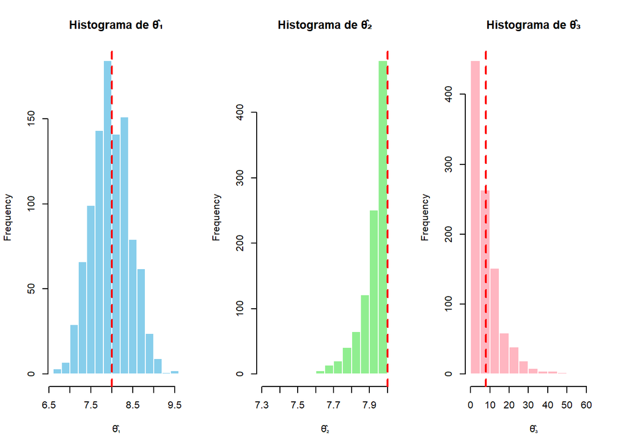

```r
par(mfrow = c(1, 3))
hist(theta1, main = "Histograma de θ̂₁", xlab = "θ̂₁", col = "skyblue", border = "white")
abline(v = theta, col = "red", lwd = 2, lty = 2)

hist(theta2, main = "Histograma de θ̂₂", xlab = "θ̂₂", col = "lightgreen", border = "white")
abline(v = theta, col = "red", lwd = 2, lty = 2)

hist(theta3, main = "Histograma de θ̂₃", xlab = "θ̂₃", col = "lightpink", border = "white")
abline(v = theta, col = "red", lwd = 2, lty = 2)
```

## Union de vectores en una matriz

```r
matriz_estimadores <- cbind(theta1, theta2, theta3)
```

## Cálculo de sesgos y varianzas

```r
# Funciones para sesgo y varianza empírica
sesgo <- function(est) mean(est) - theta
var_emp <- function(est) var(est)

# Cálculos empíricos
sesgos <- c(sesgo(theta1), sesgo(theta2), sesgo(theta3))
vars_emp <- c(var_emp(theta1), var_emp(theta2), var_emp(theta3))

# Varianzas teóricas conocidas
vars_teo <- c(
  (theta^2) / (3 * n),                              # Varianza estimador de momentos
  theta^2 * (n / (n + 2) - n^2 / (n + 1)^2),         # Varianza del máximo
  (n * theta^2) / (n + 2)                            # Varianza del mínimo ajustado
)
```

## Tabla resumen del sesgo y varianza empirica

En esta sección se calcula el sesgo y la varianza empírica de los tres estimadores considerados: método de momentos (θ̂₁), máxima verosimilitud (θ̂₂) y el estimador basado en el mínimo (θ̂₃). También se comparan estos valores con sus varianzas teóricas, tal como se discutió en clase.

```r
tabla_resultados <- tibble(
  Estimador = c("θ̂₁ (Momentos)", "θ̂₂ (Verosimilitud)", "θ̂₃ (Mínimo ajustado)"),
  Sesgo = sesgos,
  Varianza_Empírica = vars_emp,
  Varianza_Teórica = vars_teo
)

tabla_resultados
```

```
## # A tibble: 3 × 4
##   Estimador              Sesgo Varianza_Empírica Varianza_Teórica
##   <chr>                  <dbl>             <dbl>            <dbl>
## 1 θ̂₁ (Momentos)        -0.0112           0.208            0.213
## 2 θ̂₂ (Verosimilitud)   -0.0782           0.00612          0.00615
## 3 θ̂₃ (Mínimo ajustado)  0.0706          62.6             62.7
```

## Distribucion con cajas y bigotes

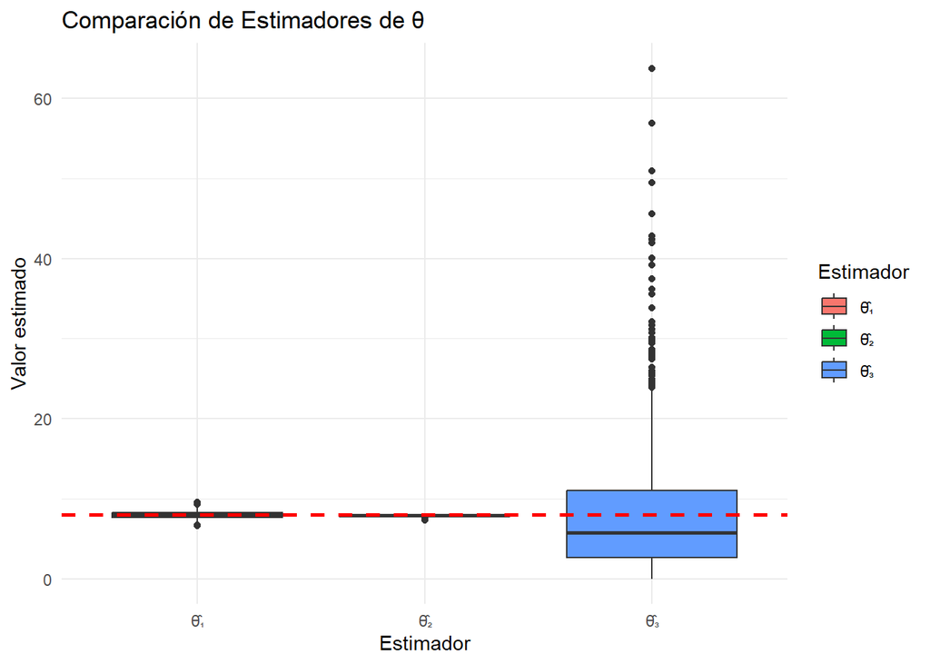

```r
# Convertir matriz a data.frame y dar nombres a las columnas
df_estimadores <- as.data.frame(matriz_estimadores)
colnames(df_estimadores) <- c("theta1", "theta2", "theta3")

# Transformar a formato largo para ggplot
datos_largos <- pivot_longer(df_estimadores, cols = everything(), names_to = "Estimador", values_to = "Valor") %>%
  mutate(Estimador = recode(Estimador,
                            "theta1" = "θ̂₁",
                            "theta2" = "θ̂₂",
                            "theta3" = "θ̂₃"))

# Gráfico de cajas
ggplot(datos_largos, aes(x = Estimador, y = Valor, fill = Estimador)) +
  geom_boxplot() +
  geom_hline(yintercept = theta, color = "red", linetype = "dashed", linewidth = 1) +
  labs(title = "Comparación de Estimadores de θ",
       x = "Estimador", y = "Valor estimado") +
  theme_minimal()
```

## Conclusiones:

Los tres estimadores evaluados tienen diferentes comportamientos respecto al sesgo y la varianza, que se explican de la siguiente manera:

1. **Estimador: Método de momentos**

Sesgo: −0.0112 → Prácticamente insesgado (muy cercano a 0).

Varianza empírica: 0.2083, muy cercana a la varianza teórica de 0.2133.

Conclusión: Este estimador presenta buen comportamiento general: bajo sesgo y varianza moderada. Es un estimador estable y consistente.

2. **Estimador: Máxima verosimilitud**

Sesgo: −0.0782 → Tiene un sesgo negativo, subestima ligeramente a 𝜃

Varianza empírica: 0.0061, muy cercana a la varianza teórica de 0.00615.

Conclusión: Aunque presenta bajo sesgo (aunque no nulo), su varianza es la más baja de los tres, lo cual lo convierte en el más preciso. Es una excelente opción si se tolera una ligera subestimación.

3. **Estimador: Minimo ajustado**

Varianza empírica: 62.58, muy cercana a la varianza teórica de 62.75.

Conclusión: Aunque su comportamiento empírico coincide con la teoría, su varianza es extremadamente alta, lo que lo hace muy inestable. Se recomienda evitarlo salvo que se necesite un estimador no basado en valores centrales.